# Re-analysis of original study (Shebani and Pulvermüller, 2013)

[Guillermo Montero-Melis](https://www.mpi.nl/people/montero-melis-guillermo)

04/09/2019

# 1 Setup workspace

```r
library("knitr")
library("lme4")
library("brms")
library("tidyverse")  # ggplot2, dplyr, readr, purrr, etc
library("boot")       # for inv.logit()
library("DescTools")  # EtaSq()
library("lsr")        # cohensD()
# library("sjstats")    # eta_sq()
```

# 2 Original data set

```r
# Load data
d_allconds <- read_csv("orig_study/SP13_orig-data_total-errors_long-format.csv")
d_allconds$subject <- factor(d_allconds$subject)
```

```r
kable(head(d_allconds))
```

| subject | movement | word_type | errors |
| --- | --- | --- | --- |
| 1 | arm_paradi | arm | 14 |
| 1 | arm_paradi | leg | 10 |
| 1 | artic_suppression | arm | 22 |
| 1 | artic_suppression | leg | 24 |
| 1 | control | arm | 9 |
| 1 | control | leg | 8 |

- The data show the total number of errors, adding all three types of errors: omissions, replacements, and transpositions.
- This data set contains the data for all four movement conditions: arm_paradi, artic_suppression, control, leg_paradi. However, we are only interested in the two critical arm/leg movement conditions, so we subset the relevant data:

```r
d <- d_allconds %>% filter(movement %in% c("arm_paradi", "leg_paradi"))
kable(head(d))
```

| subject | movement | word_type | errors |
| --- | --- | --- | --- |
| 1 | arm_paradi | arm | 14 |
| 1 | arm_paradi | leg | 10 |
| 1 | leg_paradi | arm | 18 |
| 1 | leg_paradi | leg | 21 |
| 2 | arm_paradi | arm | 2 |
| 2 | arm_paradi | leg | 2 |

```r
str(d)
```

```
## Classes 'spec_tbl_df', 'tbl_df', 'tbl' and 'data.frame': 60 obs. of  4 variables:
##  $ subject  : Factor w/ 15 levels "1","2","3","4",..: 1 1 1 1 2 2 2 2 3 3 ...
##  $ movement : chr  "arm_paradi" "arm_paradi" "leg_paradi" "leg_paradi" ...
##  $ word_type: chr  "arm" "leg" "arm" "leg" ...
##  $ errors   : num  14 10 18 21 2 2 2 3 24 18 ...
##  - attr(*, "spec")=
##   .. cols(
##   ..   subject = col_double(),
##   ..   movement = col_character(),
##   ..   word_type = col_character(),
##   ..   errors = col_double()
##   .. )
```

Plot the data:

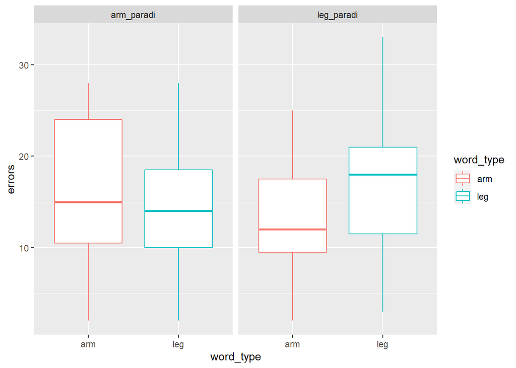

```r
ggplot(d, aes(x = word_type, y = errors, colour = word_type)) +
  geom_boxplot() +
  facet_grid(. ~ movement)
```

We can qualitatively see the cross-over interaction. Note that although the variability is large, the effect is still able to come out if there is sufficient consistency within subjects, as it is a within-subjects design. This can be better appreciated in the following plot:

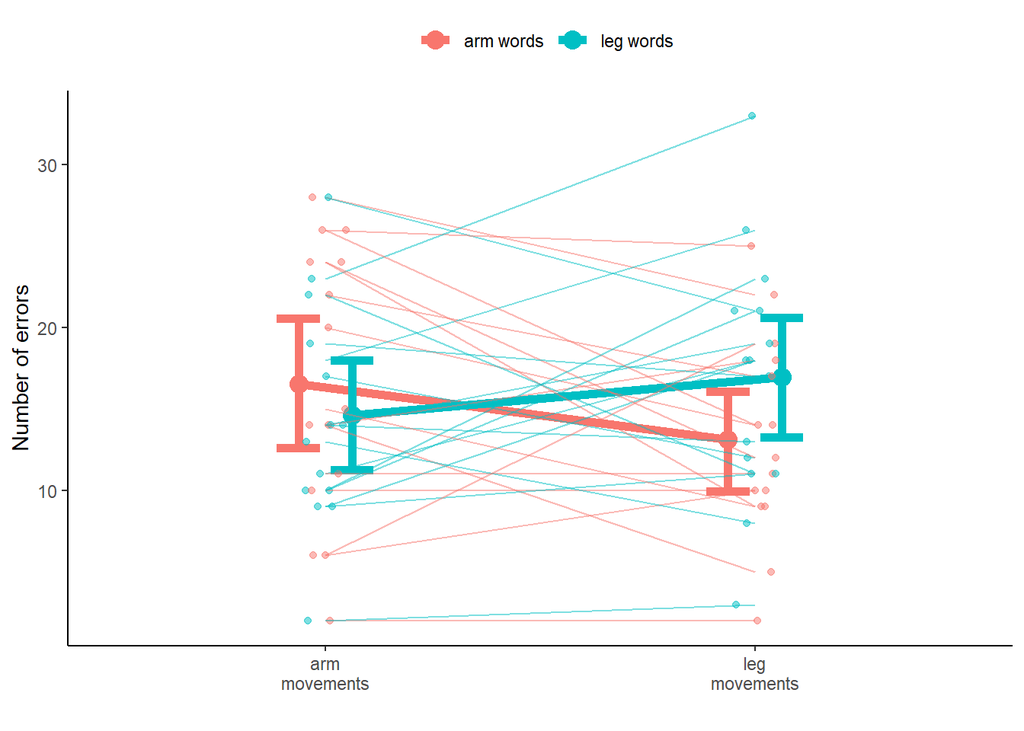

The thick dots and lines show mean number of errors and bootstrapped (non-parametric) 95% CIs. The thinner dots and lines show subject data. There seems to be quite a lot of consistency by subjects, i.e. the slopes of the thin lines mostly go in the same direction as the slope of the thicker lines.

# 3 Replicate originally reported analysis with ANOVAs

## 3.1 Data summaries

First, let’s see if our data summaries look like theirs reported in Table 2 (SP13, p.226):

```r
d_allconds %>%
  group_by(movement, word_type) %>%
  summarise(
    M  = round(mean(errors), 1),
    SD = round(sd(errors), 2)
  )
```

```
## # A tibble: 8 x 4
## # Groups:   movement [4]
##   movement          word_type     M    SD
##   <chr>             <chr>     <dbl> <dbl>
## 1 arm_paradi        arm        16.5  8.39
## 2 arm_paradi        leg        14.6  6.66
## 3 artic_suppression arm        22    7.69
## 4 artic_suppression leg        19.6  5.91
## 5 control           arm         7.2  4.97
## 6 control           leg         8.3  4.19
## 7 leg_paradi        arm        13.1  6.23
## 8 leg_paradi        leg        16.9  7.56
```

Yes, this replicates the values in Table 2!

## 3.2 Anova on full 4 (conditions) x 2 (word categories) design:

Can we replicate the results reported in SP13 (p.225)?

```r
# Following this post:
# https://www.r-bloggers.com/two-way-anova-with-repeated-measures/
aov_orig_allconds <- aov(
  errors ~ movement * word_type +
    Error(subject / (movement * word_type)),
  data = d_allconds)
summary(aov_orig_allconds)
```

```
##
## Error: subject
##           Df Sum Sq Mean Sq F value Pr(>F)
## Residuals 14   2801   200.1
##
## Error: subject:movement
##           Df Sum Sq Mean Sq F value   Pr(>F)
## movement   3   2583   861.1   23.77 3.77e-09 ***
## Residuals 42   1522    36.2
## ---
## Signif. codes:  0 '***' 0.001 '**' 0.01 '*' 0.05 '.' 0.1 ' ' 1
##
## Error: subject:word_type
##           Df Sum Sq Mean Sq F value Pr(>F)
## word_type  1   0.68   0.675   0.049  0.828
## Residuals 14 192.70  13.764
##
## Error: subject:movement:word_type
##                    Df Sum Sq Mean Sq F value   Pr(>F)
## movement:word_type  3  188.5   62.83   7.635 0.000349 ***
## Residuals          42  345.6    8.23
## ---
## Signif. codes:  0 '***' 0.001 '**' 0.01 '*' 0.05 '.' 0.1 ' ' 1
```

Yes, pretty much: The F-values are identical, but I don’t know how they computed MSE. Their numbers don’t line up with the current results.

## 3.3 Anova on critical 2x2 design

Most importantly, can we replicate the critical results “directly addressing the main hypothesis motivating this study” (SP13, p.226)?

```r
aov_orig <- aov(errors ~ movement * word_type +
                  Error(subject / (movement * word_type)),
                data = d)
summary(aov_orig)
```

```
##
## Error: subject
##           Df Sum Sq Mean Sq F value Pr(>F)
## Residuals 14   2039   145.7
##
## Error: subject:movement
##           Df Sum Sq Mean Sq F value Pr(>F)
## movement   1    4.3    4.27   0.096  0.761
## Residuals 14  620.2   44.30
##
## Error: subject:word_type
##           Df Sum Sq Mean Sq F value Pr(>F)
## word_type  1  13.07   13.07   1.169  0.298
## Residuals 14 156.43   11.17
##
## Error: subject:movement:word_type
##                    Df Sum Sq Mean Sq F value  Pr(>F)
## movement:word_type  1  123.3  123.27   12.67 0.00314 **
## Residuals          14  136.2    9.73
## ---
## Signif. codes:  0 '***' 0.001 '**' 0.01 '*' 0.05 '.' 0.1 ' ' 1
```

Again, pretty much yes: The F-values, degrees of freedom and p-values are identical. Still their reported MSE differs from what we obtained above.

## 3.4 Effect size: Where does the originally reported Cohen’s $d$ come from?

The authors report Cohen’s $d = 1.25$ as the effect size for the critical interaction (p.226). However, it is not clear how they arrived at this figure.

### 3.4.1 Does the *d* value come from a t-test?

What if we compare the average difference scores corresponding to the interaction effect, i.e. we compare for each subject the average number of errors when effector and word type coincide (arm-arm or leg-leg) and when they differ (arm-leg or leg-arm):

```r
d$eff_word <- ifelse(substr(d$movement,1,3) == d$word_type, "same", "diff")
head(d, 4)
```

```
## # A tibble: 4 x 5
##   subject movement   word_type errors eff_word
##   <fct>   <chr>      <chr>      <dbl> <chr>
## 1 1       arm_paradi arm           14 same
## 2 1       arm_paradi leg           10 diff
## 3 1       leg_paradi arm           18 diff
## 4 1       leg_paradi leg           21 same
```

```r
d_interact <- d %>%
  group_by(subject, eff_word) %>%
  summarise(errors = mean(errors))
head(d_interact)
```

```
## # A tibble: 6 x 3
## # Groups:   subject [3]
##   subject eff_word errors
##   <fct>   <chr>     <dbl>
## 1 1       diff       14
## 2 1       same       17.5
## 3 2       diff        2
## 4 2       same        2.5
## 5 3       diff       13.5
## 6 3       same       25
```

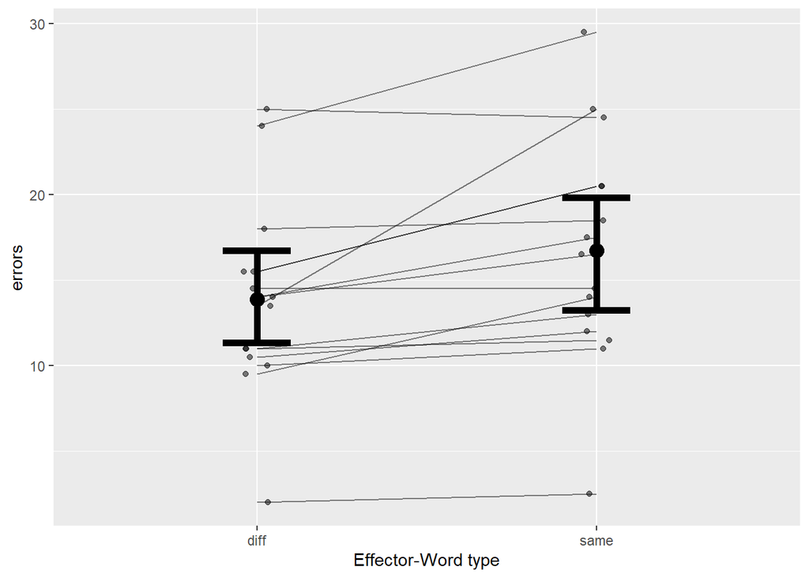

```r
ggplot(d_interact, aes(x = eff_word, y = errors)) +
  geom_jitter(height = 0, width = .05, alpha = .5) +
  geom_line(aes(group = subject), alpha = .5) +
  stat_summary(fun.y = mean, geom = "point", size = 4,
               position = position_dodge(width = .25)) +
  stat_summary(fun.data = mean_cl_boot, geom = "errorbar", width = 0.2, size = 2,
               position = position_dodge(width = .25)) +
  xlab("Effector-Word type")
```

```r
d_4ttest <- spread(d_interact, eff_word, errors)
head(d_4ttest, 3)
```

```
## # A tibble: 3 x 3
## # Groups:   subject [15]
##   subject  diff  same
##   <fct>   <dbl> <dbl>
## 1 1        14    17.5
## 2 2         2     2.5
## 3 3        13.5  25
```

```r
with(d_4ttest, t.test(diff, same, paired = TRUE))
```

```
##
##  Paired t-test
##
## data:  diff and same
## t = -3.5591, df = 14, p-value = 0.003143
## alternative hypothesis: true difference in means is not equal to 0
## 95 percent confidence interval:
##  -4.594159 -1.139174
## sample estimates:
## mean of the differences
##               -2.866667
```

Cohen’s $d$:

```r
# Following https://rcompanion.org/handbook/I_04.html
with(d_4ttest, (mean(same) - mean(diff)) / sd(same - diff))
```

```
## [1] 0.9189662
```

```r
# # Note we get the same value using the lsr package
# with(d_4ttest, lsr::cohensD(diff, same, method = "paired"))
```

No; we obtain a Cohen’s $d = 0.92$, unlike the figure reported in SP13.

### 3.4.2 Computing $d$ from $\eta^2$?

Eta squared ($\eta^2$) is the most commonly used measure of effect size for ANOVAs: It “measures the proportion of the total variance in a dependent variable that is associated with […] an independent variable” (Richardson, 2011, p. 135; for an example calculation, see [here](https://psychohawks.wordpress.com/2010/10/31/effect-size-for-analysis-of-variables-anova/)).

```r
eta_sq <- DescTools::EtaSq(aov_orig, type = 1)
eta_sq
```

```
##                         eta.sq eta.sq.part  eta.sq.gen
## movement           0.001379637 0.006832132 0.001443262
## word_type          0.004225140 0.077089479 0.004406871
## movement:word_type 0.039858587 0.475016057 0.040083245
```

```r
# sjstats::eta_sq(aov_orig)  # yields same results
```

The value for the critical movement–word type interaction interaction of interest is $\eta^2 = 0.04$.

We tried two methods of converting $\eta^2$ to Cohen’s $d$:

1. [This online calculator](https://www.psychometrica.de/effect_size.html) converts between different effect size measures (see section 13). When plugging in $\eta^2 = 0.04$, the corresponding effect size is $d = 0.41$, which is far off from the figure reported in SP13!
2. [This IBM support website](https://www-01.ibm.com/support/docview.wss?uid=swg21476421) cites formulae to convert between Eta-squared, Cohen’s $f$, and Cohen’s $d$:
   $$f = \sqrt{ \frac{\eta^2}{1 - \eta^2} };
   d = 2*f$$
   This formula yields the same value as above ($d=0.41$) if the `eta.sq` value is plugged in. (If we use the `eta.sq.part` value instead, it seems completely off with $d$ close to 2.) Either way it doesn’t match the value reported in SP13.

## 3.5 Conclusion

While we are able to replicate the descriptive statistics and the ANOVA results reported in SP13 from the data the authors shared with us, we are unable to reproduce their reported effect size value of Cohen’s $d = 1.25$ (SP13, p. 226). The two methods we have tried yield either $d=0.92$ or $d=0.41$.

# 4 Treat data as coming from a binomial distribution, but what is $n$?

SP13 analyzed their data using ANOVAs and t-tests. We instead want to model the dependent variable (DV = number of errors per experimental cell) as coming from a binomial distribution:

$$errors \sim B(n, p)$$

Here, $n$ is the upper bound on the possible number of errors and $p$ is the probability of making an error for each word. We will assume that the maximum number of errors for each trial (i.e., sequence of 4 words) is 4. However, we also need to determine how many trials there were per cell and this is slightly tricky, because SP13 report this inconsistently.

## 4.1 Email correspondence with authors

We emailed the original authors about this. Here is the relevant extract, with the authors’ responses as inline comments (email correspondence with Z. Shebani from 1 Apr 2018):

> **Number of trials**

> It says that 24 trials were presented in each block, twelve arm-word and 12 leg-word trials (sect. 2.3, p.225 left column [=LC]). It also says that 4 words were presented per trial (sect. 2.3, p.224 right column [=RC]). This implies that 48 words of each category were shown per block. Since the lists consist of 36 words per category, the above would suggest that some words were repeated in each block (e.g., 12 words per category repeated once), but this is not explicitly stated. Was this the case?

> > Yes, 48 words from each category were shown in each block. Twelve words per category, randomly selected, were repeated once in each block.

> It then says that conditions were run as separate blocks (sect. 2.3, p.225 LC) and that the full set of 72 words were presented twice in each condition (sect. 2.3, p.225 RC). These figures don’t seem to add up: For 72 * 2 = 144 words to be presented, this would require 144 / 4 = 36 trials (assuming 4 words are presented in each trial). In other words, one would need 1.5 blocks per condition, whereas in the study it says that “the conditions were run as separate blocks with twenty-four trials in each block” (p.225). Is there perhaps a typo in the reported numbers, or do we err in our reasoning? In sum, what was the exact number of words per trial, trials per block (we assume equal number of leg- and arm-word trials), and blocks per condition?

> > Line 2 of page 225, RC does indeed contain a typo. As mentioned above, 48 words from each category were presented in each block (36 +12 = 48), therefore, not all words were repeated twice in each block/condition. In sum: Words per trial: 4 Trials per block: 24 (12 arm word and 12 leg word trials) Blocks in the experiment: 4 Blocks per condition: 1

## 4.2 We set $n = 48$

Based on this correspondence, we take there to be 12 trials per experimental cell. Since we assume the maximum number of errors per trial is 4, $n = 12 \times 4 = 48$.

```r
d$n <- 48
```

# 5 Bayesian GLMM (binomial mixed model) with *brms*

We fit a binomial model using the default options for priors. (For the syntax of how to specify the response variable in a binomial model, see Bürkner 2017, p.7, fn 3.)

## 5.1 Fit model

First, set coding scheme to contrast coding:

```r
# movement condition
d$movement <- factor(d$movement)
contrasts(d$movement) <- contr.sum(2)
colnames(contrasts(d$movement)) <- "arm_vs_leg"
contrasts(d$movement)
```

```
##            arm_vs_leg
## arm_paradi          1
## leg_paradi         -1
```

```r
# word type
d$word_type <- factor(d$word_type)
contrasts(d$word_type) <- contr.sum(2)
colnames(contrasts(d$word_type)) <- "arm_vs_leg"
contrasts(d$word_type)
```

```
##     arm_vs_leg
## arm          1
## leg         -1
```

Fit the model

```r
# bfm_binom <- brm(errors | trials(n) ~ 1 + movement * word_type + (1 | subject),
#                  data = d,
#                  family = "binomial",
#                  warmup = 2000, iter = 7000)
# # To save time, save fitted model to file
# saveRDS(bfm_binom, "sims_etc/bayes_glmm_default.rds")
```

Once saved to disk, load it:

```r
bfm_binom <- readRDS("sims_etc/bayes_glmm_default.rds")
```

## 5.2 Model summary and interpretation

```r
summary(bfm_binom)
```

```
##  Family: binomial
##   Links: mu = logit
## Formula: errors | trials(n) ~ 1 + movement * word_type + (1 | subject)
##    Data: d (Number of observations: 60)
## Samples: 4 chains, each with iter = 7000; warmup = 2000; thin = 1;
##          total post-warmup samples = 20000
##
## Group-Level Effects:
## ~subject (Number of levels: 15)
##               Estimate Est.Error l-95% CI u-95% CI Eff.Sample Rhat
## sd(Intercept)     0.76      0.18     0.49     1.19       3732 1.00
##
## Population-Level Effects:
##                                        Estimate Est.Error l-95% CI
## Intercept                                 -0.85      0.21    -1.26
## movementarm_vs_leg                         0.03      0.04    -0.05
## word_typearm_vs_leg                       -0.05      0.04    -0.13
## movementarm_vs_leg:word_typearm_vs_leg     0.15      0.04     0.07
##                                        u-95% CI Eff.Sample Rhat
## Intercept                                 -0.44       2623 1.00
## movementarm_vs_leg                         0.11      16266 1.00
## word_typearm_vs_leg                        0.03      17071 1.00
## movementarm_vs_leg:word_typearm_vs_leg     0.23      17086 1.00
##
## Samples were drawn using sampling(NUTS). For each parameter, Eff.Sample
## is a crude measure of effective sample size, and Rhat is the potential
## scale reduction factor on split chains (at convergence, Rhat = 1).
```

Interpretation (backtransforming to odds):

- The estimated average odds of an error (intercept) is $e ^ {-0.85} = 0.43$ (corresponding to a probability of 0.3)
- Neither the type of movement (`movement`) nor the type of word (`word_type`) have a significant effect on the odds of making an error.
- The critical interaction, however, is significant and tells us that the odds of making an error if the effector of the movement *coincides* with the word type (as opposed to when the two differ) is $e ^ {0.15} =1.16$. In other words, participants were 1.16 times more likely to make an error if effector and semantics match than if they mismatch. This is the *interference effect* of interest!

## 5.3 Effect size

This is a very small effect size…

## 5.4 But is the effect really supported by the data?

*brms* allows us to perform “non-linear hypothesis testing”. This lets us test the hypothesis that the crucial interaction is larger than zero (i.e., there is an interference effect):

```r
hypothesis(bfm_binom, "movementarm_vs_leg:word_typearm_vs_leg > 0")
```

```
## Hypothesis Tests for class b:
##                 Hypothesis Estimate Est.Error CI.Lower CI.Upper Evid.Ratio
## 1 (movementarm_vs_l... > 0     0.15      0.04     0.08     0.22    6665.67
##   Post.Prob Star
## 1         1    *
## ---
## 'CI': 90%-CI for one-sided and 95%-CI for two-sided hypotheses.
## '*': For one-sided hypotheses, the posterior probability exceeds 95%;
## for two-sided hypotheses, the value tested against lies outside the 95%-CI.
## Posterior probabilities of point hypotheses assume equal prior probabilities.
```

The evidence ratio that there exists an interference effect is overwhelming.

We can also plot the posterior distribution of the model estimates:

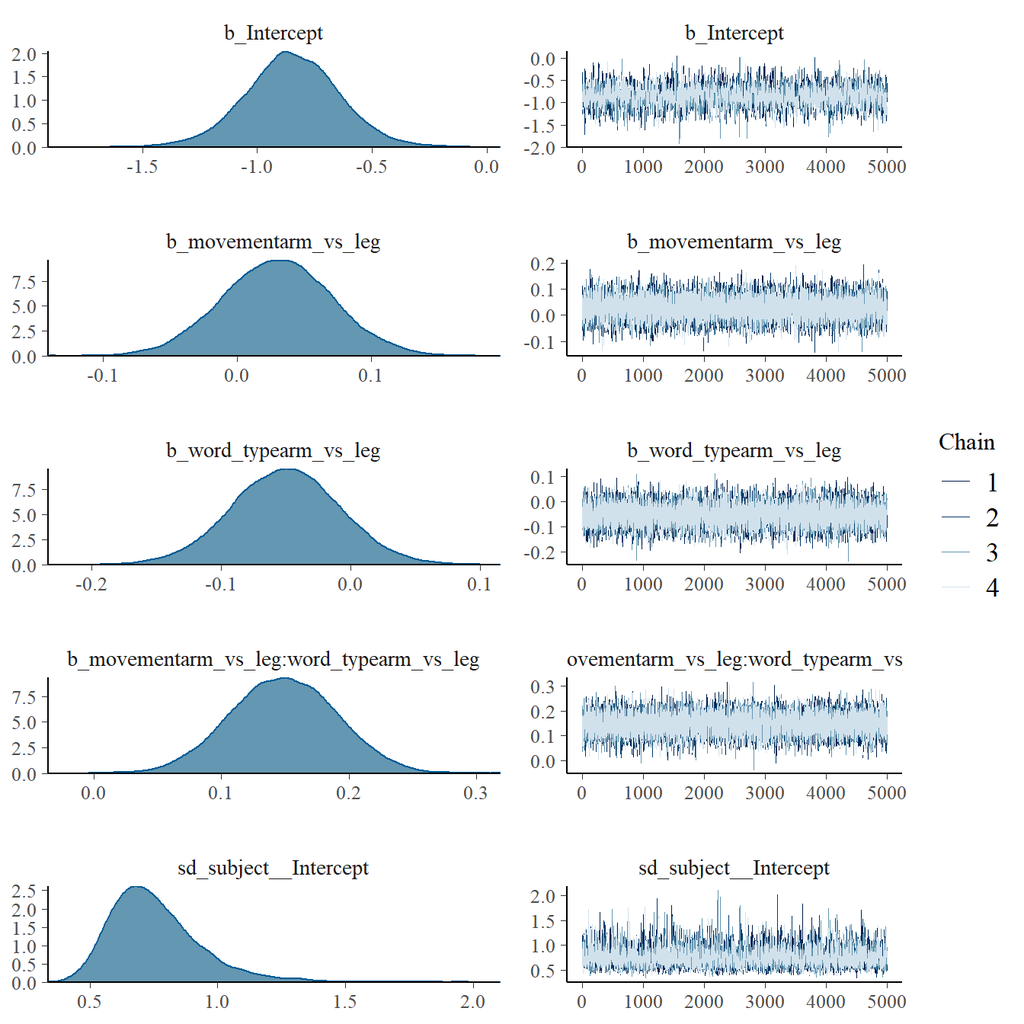

```r
plot(bfm_binom)
```

# 6 Save posterior distribution of interaction coefficient to use as effect size prior for BFDA

*brms* has a `posterior_samples(x, pars)` function to get posterior traces for specific coefficients. We pass our fitted *brms* model as x, and the predictor of interest as pars, and obtain a dataframe with the samples in return.

This posterior from the original we can then use as the prior for the design analysis in our replication.

```r
beta_posterior <- posterior_samples(bfm_binom, "movementarm_vs_leg:word_typearm_vs_leg")
write_csv(beta_posterior, "sims_etc/beta_posterior.csv")
```

# 7 GLMM with *lme4*

We start by fitting a frequentist GLMM with *lme4* for a first quick interpretation of the estimated model coefficients.

## 7.1 Binomial GLMM

```r
fm_binom <- glmer(cbind(errors, n - errors) ~ 1 + movement * word_type +
                    (1 | subject),
                  data = d, family = "binomial")
summary(fm_binom)
```

```
## Generalized linear mixed model fit by maximum likelihood (Laplace
##   Approximation) [glmerMod]
##  Family: binomial  ( logit )
## Formula:
## cbind(errors, n - errors) ~ 1 + movement * word_type + (1 | subject)
##    Data: d
##
##      AIC      BIC   logLik deviance df.resid
##    399.1    409.6   -194.5    389.1       55
##
## Scaled residuals:
##     Min      1Q  Median      3Q     Max
## -3.0041 -0.8189 -0.1012  0.8675  2.2297
##
## Random effects:
##  Groups  Name        Variance Std.Dev.
##  subject (Intercept) 0.4319   0.6572
## Number of obs: 60, groups:  subject, 15
##
## Fixed effects:
##                                        Estimate Std. Error z value
## (Intercept)                            -0.84189    0.17530  -4.802
## movementarm_vs_leg                      0.02979    0.04147   0.718
## word_typearm_vs_leg                    -0.04949    0.04147  -1.193
## movementarm_vs_leg:word_typearm_vs_leg  0.14793    0.04149   3.566
##                                        Pr(>|z|)
## (Intercept)                            1.57e-06 ***
## movementarm_vs_leg                     0.472472
## word_typearm_vs_leg                    0.232732
## movementarm_vs_leg:word_typearm_vs_leg 0.000363 ***
## ---
## Signif. codes:  0 '***' 0.001 '**' 0.01 '*' 0.05 '.' 0.1 ' ' 1
##
## Correlation of Fixed Effects:
##             (Intr) mvmn__ wrd___
## mvmntrm_vs_ -0.003
## wrd_typrm__  0.005 -0.047
## mvmnt__:___ -0.013  0.018 -0.013
```

Interpretation (backtransforming to odds):

- The estimated average odds of making an error (intercept) is $e ^ {-0.84} = 0.43$ (corresponding to a probability of 0.3)
- Neither movement condition (`movement`) or the type of word (`word_type`) have a significant effect on the odds of making an error per se (i.e., no main effects).
- The critical interaction, however, is significant and tells us that the odds of making an error if the effector of the movement *coincides* with the word type (as opposed to when the two differ) is $e ^ {0.15} =1.16$. In other words, participants were 1.16 times more likely to make an error if effector and semantics match than if they mismatch. This is the *interference effect* of interest!

The point estimates are virtually identical in the *brms* and *lme4* models. The *brms* model also features 95% credible intervals for parameter estimates. The 95% credible interval for the critical interaction $[0.07, 0.23]$ clearly contains the point estimate from the *lme4* model, and the two are identical (*brms*: $0.149$; *lme4*: $0.148$). Note that the estimated SEM also are quite comparable.

# 8 Is the effect we find in the sample robust? Apply bootstrapping!

Markus suggested that the apparently robust interaction effect observed in the original data might hinge on just a few participants who are driving the effect. One way of assessing this is through bootstrapping.

Bootstrap procedure:

1. Take a random sample of size 15 with replacement from the 15 participants in the original study.
2. Analyze the data set with the *lme4* model above (faster than *brms*).
3. Extract the estimates for the coefficient and its SE.
4. Repeat steps 1–3 a large number of times (e.g., 5000)

## 8.1 Bootstrapping

Basic function:

```r
# Function for a single run:
mybootstr <- function(df = d) {

  # Create new data set by resampling Subjects with replacement
  # (NB: Relies on dplyr functions, see in particular nest())
  newd <- df %>%
    nest(-subject) %>%
    sample_n(15, replace = TRUE) %>%
    mutate(subject = 1 : 15) %>%  # assign each resampled S a unique ID
    unnest()

  # contrast coding for movement and wordtype
  newd$movement <- factor(newd$movement)
  contrasts(newd$movement) <- contr.sum(2)
  newd$word_type <- factor(newd$word_type)
  contrasts(newd$word_type) <- contr.sum(2)

  # Fit glmer model
  fm_binom <- glmer(
    cbind(errors, n - errors) ~ 1 + movement * word_type + (1 | subject),
    data = newd, family = "binomial"
    )

  # extract point estimate and SE for interaction coefficient of interest, based
  # on https://r.789695.n4.nabble.com/extracting-coefficients-from-lmer-td791247.html
  beta <- fixef(fm_binom)[4]
  SE   <- sqrt(diag(vcov(fm_binom, useScale = FALSE))[4])
  zval <- beta / SE
  # out
  out <- c(beta, SE, zval)
  names(out) <- c("beta", "SE", "zval")
  out
}
```

Call it once or 4 times (with `replicate()`):

```r
# Run once
mybootstr()
```

```
##       beta         SE       zval
## 0.15664919 0.04033529 3.88367559
```

```r
# Using replicate
data.frame(t(replicate(4, mybootstr())))
```

```
##        beta         SE     zval
## 1 0.1260292 0.04094403 3.078083
## 2 0.1047568 0.04315888 2.427235
## 3 0.1748606 0.04392164 3.981194
## 4 0.1275626 0.04048127 3.151152
```

Run the function a large number of times and save results:

```r
# # Run and save to disk
# bootstr_res <- data.frame(t(replicate(5000, mybootstr())))
# write_csv(bootstr_res, "sims_etc/bootstrap_results.csv")
```

Once run, read from disk:

```r
# Read from disk
bootstr_res <- read_csv("sims_etc/bootstrap_results.csv")
# str(bootstr_res)
head(bootstr_res)
```

```
## # A tibble: 6 x 3
##    beta     SE  zval
##   <dbl>  <dbl> <dbl>
## 1 0.136 0.0415  3.28
## 2 0.132 0.0411  3.21
## 3 0.151 0.0408  3.70
## 4 0.139 0.0423  3.28
## 5 0.118 0.0408  2.90
## 6 0.143 0.0415  3.45
```

## 8.2 Plot results

We plot the distribution of

1. beta estimates for the coefficient of interest (the critical interaction)
2. the SE for that coefficient
3. the $z$-value for that coefficient (this is just the ratio of the two above)

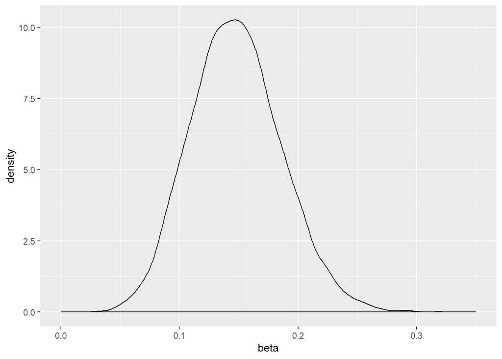

```r
ggplot(bootstr_res, aes(x = beta)) +
  geom_density() + xlim(0, 0.35)
```

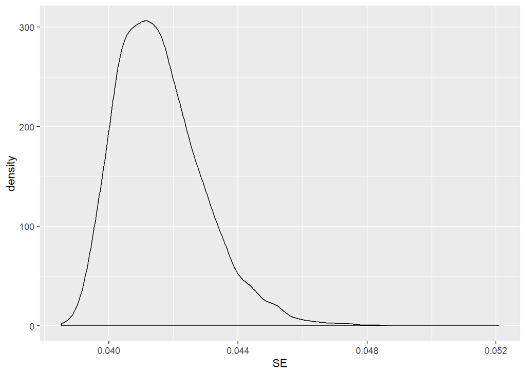

```r
ggplot(bootstr_res, aes(x = SE)) +
  geom_density()
```

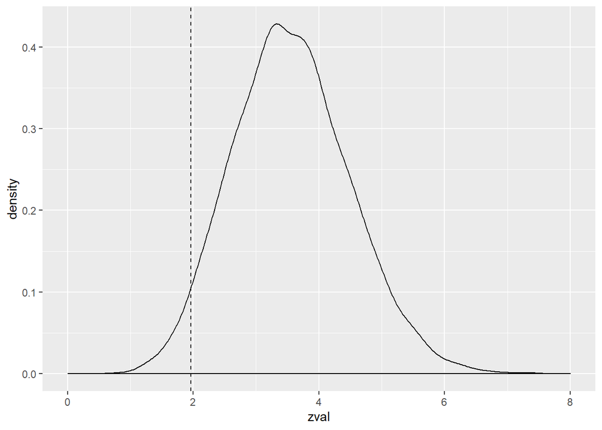

```r
ggplot(bootstr_res, aes(x = zval)) +
  geom_density() + xlim(0, 8) +
  geom_vline(xintercept = 1.96, linetype = "dashed")
```

What is the proportion of runs in which $z < 1.96$ (i.e., a non-significant effect)?

```r
with(bootstr_res, sum(zval < 1.96) / length(zval))
```

```
## [1] 0.0326
```

Based on bootstrapping it does not seem that the effect is very sensitive to a few exceptional participants within the sample. But of course it could still be that the sampled data itself (in the experiment) was exceptional, leading to a conclusion that would not scale up to the larger population (or it might not even replicate within that participant sample if the experiment was run anew with the same participants).